# DATA 607: Tidy Data, Project 2

VINAYAK PATEL

October 7, 2018

# Environment Prep

```r
if (!require('dplyr')) install.packages('dplyr')
if (!require('tidyr')) install.packages('tidyr')
if (!require('DT')) install.packages('DT')
if (!require('ggplot2')) install.packages('ggplot2')
if (!require('xlsx')) install.packages('xlsx')
if (!require('reshape2')) install.packages('reshape2')
```

# Dataset 1: Occupational Wages for the New York City Region

- **Ref:** labor.ny.gov
- **Data Source:** Employment and wage data by occupation are based on the Occupational Employment Statistics (OES) survey, which collects information from approximately 51,000 businesses. Estimates are based on responses from six semi-annual panels collected between November 2014 and May 2017. Wages were then updated to the first quarter of 2018 by making cost-of-living adjustments. Occupational employment and wages are presented for New York State and its 10 labor market regions.
- **Data Citation:** Occupational Wages for the New York City Region: November,2014 and May, 2017 Source: labor.ny.gov
- **Additional Information:** [The entire set of currently available OES employment and wage data is available by downloading the file](https://labor.ny.gov/stats/lswage2.asp)

## Abstract

Let’s revise the original question offerings, knowing that these are projections based on sample data of 51000 business. * Most no.jobs available at based on occupations category? * Which top 10 jobs are high paying job?

## Data Import

```r
labor <- read.csv("wagesCSV.csv", header=TRUE,stringsAsFactors = FALSE)
datatable(labor)
```

|  | SOCCode | Title | Employment | Mean | Median | Entry | Experienced.. |
| --- | --- | --- | --- | --- | --- | --- | --- |
| 1 | 11-0000 | Management Occupations | 249290 | 177490 | 156350 | 86230 | 223130 |
| 2 | 11-1011 | Chief Executives | 5420 | 261580 |  |  |  |
| 3 | 11-1021 | General and Operations Managers | 78000 | 179900 | 159020 | 76290 | 231700 |
| 4 | 11-1031 | Legislators |  | 143760 | 139130 | 109860 | 160710 |
| 5 | 11-2011 | Advertising and Promotions Managers | 5290 | 182060 | 164800 | 97030 | 224580 |
| 6 | 11-2021 | Marketing Managers | 11970 | 208560 | 192370 | 127360 | 249160 |
| 7 | 11-2022 | Sales Managers | 12970 | 226010 | 212230 | 126830 | 275610 |
| 8 | 11-2031 | Public Relations and Fundraising Managers | 4500 | 181870 | 162330 | 103350 | 221130 |
| 9 | 11-3011 | Administrative Services Managers | 10070 | 148580 | 136710 | 89790 | 177970 |
| 10 | 11-3021 | Computer and Information Systems Managers | 16830 | 211000 | 192020 | 129190 | 251910 |

[output cut: 669 more lines]

## Data Prep

```r
#remove NA
df<- na.omit(labor)
datatable(df)
```

|  | SOCCode | Title | Employment | Mean | Median | Entry | Experienced.. |
| --- | --- | --- | --- | --- | --- | --- | --- |
| 1 | 11-0000 | Management Occupations | 249290 | 177490 | 156350 | 86230 | 223130 |
| 3 | 11-1021 | General and Operations Managers | 78000 | 179900 | 159020 | 76290 | 231700 |
| 5 | 11-2011 | Advertising and Promotions Managers | 5290 | 182060 | 164800 | 97030 | 224580 |
| 6 | 11-2021 | Marketing Managers | 11970 | 208560 | 192370 | 127360 | 249160 |
| 7 | 11-2022 | Sales Managers | 12970 | 226010 | 212230 | 126830 | 275610 |
| 8 | 11-2031 | Public Relations and Fundraising Managers | 4500 | 181870 | 162330 | 103350 | 221130 |
| 9 | 11-3011 | Administrative Services Managers | 10070 | 148580 | 136710 | 89790 | 177970 |
| 10 | 11-3021 | Computer and Information Systems Managers | 16830 | 211000 | 192020 | 129190 | 251910 |
| 12 | 11-3051 | Industrial Production Managers | 940 | 156950 | 142980 | 84690 | 193080 |
| 13 | 11-3061 | Purchasing Managers | 1760 | 157440 | 144700 | 92550 | 189880 |

[output cut: 531 more lines]

```r
# delete All Total in category
clean_data<- df[!grepl("-0000", df$SOCCode),]
datatable(clean_data)
```

|  | SOCCode | Title | Employment | Mean | Median | Entry | Experienced.. |
| --- | --- | --- | --- | --- | --- | --- | --- |
| 3 | 11-1021 | General and Operations Managers | 78000 | 179900 | 159020 | 76290 | 231700 |
| 5 | 11-2011 | Advertising and Promotions Managers | 5290 | 182060 | 164800 | 97030 | 224580 |
| 6 | 11-2021 | Marketing Managers | 11970 | 208560 | 192370 | 127360 | 249160 |
| 7 | 11-2022 | Sales Managers | 12970 | 226010 | 212230 | 126830 | 275610 |
| 8 | 11-2031 | Public Relations and Fundraising Managers | 4500 | 181870 | 162330 | 103350 | 221130 |
| 9 | 11-3011 | Administrative Services Managers | 10070 | 148580 | 136710 | 89790 | 177970 |
| 10 | 11-3021 | Computer and Information Systems Managers | 16830 | 211000 | 192020 | 129190 | 251910 |
| 12 | 11-3051 | Industrial Production Managers | 940 | 156950 | 142980 | 84690 | 193080 |
| 13 | 11-3061 | Purchasing Managers | 1760 | 157440 | 144700 | 92550 | 189880 |
| 14 | 11-3071 | Transportation, Storage, and Distribution Managers | 1500 | 119630 | 116030 | 83920 | 137480 |

[output cut: 510 more lines]

## Analysis (Including Plots)

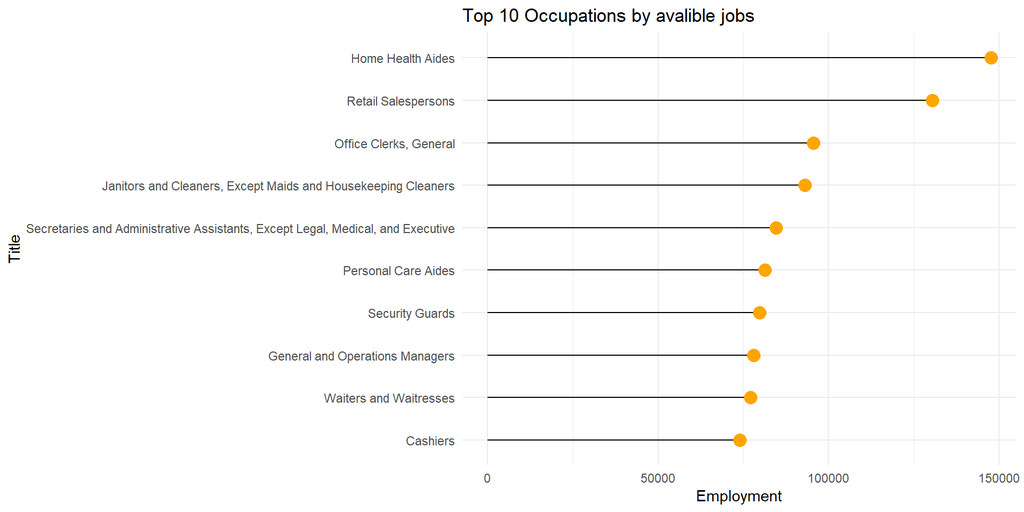

```r
#for top 10 occupations by avalible job
df_e<-as.data.frame(head(arrange(clean_data,desc(Employment)), n = 10))
lst_Employ <- df_e[] %>%
    select(Title, Employment)

# Plot
lst_Employ[] %>%
  arrange(Employment) %>%
  mutate(Title=factor(Title, levels=Title)) %>%
  ggplot( aes(x=Title, y=Employment)) +
    geom_segment( aes(xend=Title, yend=1)) +
    geom_point( size=4, color="orange") +
    coord_flip() + labs(title="Top 10 Occupations by avalible jobs") +
    theme_minimal()
```

```r
#Higest Paying job
highest_mean<-as.data.frame(head(arrange(clean_data,desc(Mean)), n = 10))
datatable(highest_mean)
```

|  | SOCCode | Title | Employment | Mean | Median | Entry | Experienced.. |
| --- | --- | --- | --- | --- | --- | --- | --- |
| 1 | 11-2022 | Sales Managers | 12970 | 226010 | 212230 | 126830 | 275610 |
| 2 | 11-3021 | Computer and Information Systems Managers | 16830 | 211000 | 192020 | 129190 | 251910 |
| 3 | 29-1066 | Psychiatrists | 2240 | 209540 | 199260 | 99410 | 264600 |
| 4 | 11-2021 | Marketing Managers | 11970 | 208560 | 192370 | 127360 | 249160 |
| 5 | 29-1067 | Surgeons | 660 | 196890 | 210100 | 67960 | 261350 |
| 6 | 29-1151 | Nurse Anesthetists | 660 | 193550 | 172000 | 128810 | 225920 |
| 7 | 29-1063 | Internists, General | 1150 | 191990 | 188590 | 68430 | 253760 |
| 8 | 23-1011 | Lawyers | 50200 | 188850 | 169790 | 86420 | 240060 |
| 9 | 41-3031 | Securities, Commodities, and Financial Services Sales Agents | 49480 | 184670 | 168180 | 75310 | 239350 |
| 10 | 29-1062 | Family and General Practitioners | 720 | 183490 | 172060 | 107050 | 221710 |

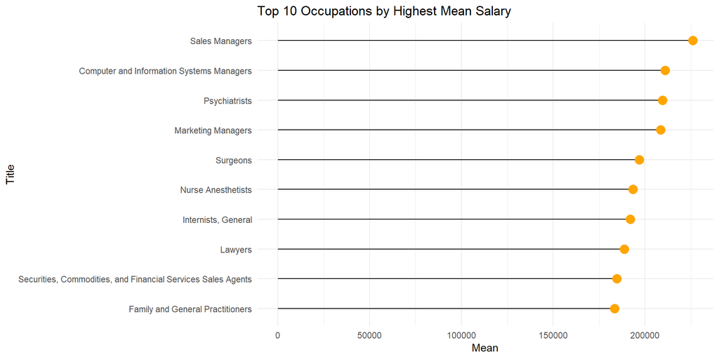

```r
highest_mean[] %>%
  arrange(Mean) %>%
  mutate(Title=factor(Title, levels=Title)) %>%
  ggplot( aes(x=Title, y=Mean)) +
    geom_segment( aes(xend=Title, yend=1)) +
    geom_point( size=4, color="orange") +
    coord_flip() + labs(title="Top 10 Occupations by Highest Mean Salary")+
    theme_minimal()
```

# Dataset 2: Predicting The Mega Millions Lottery

- **Data Source:** Lottery Mega Millions Winning Numbers Repository [Source](https://catalog.data.gov/dataset/lottery-mega-millions-winning-numbers-beginning-2002)
- **Data Citation:** Data.gov [Link](https://catalog.data.gov/dataset/lottery-mega-millions-winning-numbers-beginning-2002)

## Abstract

Can you really predict the winning lottery numbers? I am going to find some of the most common winning lottery numbers in last 10 years.

## Data Import

Lottery Mega Millions Winning Numbers: Beginning 2002. I used that file to create the .csv imported below.

```r
lotto <- read.csv("Lottery_Mega_Millions_Winning_Numbers__Beginning_2002.csv", header=TRUE,stringsAsFactors = FALSE)
head(lotto, n=20)
```

```
   Draw.Date Winning.Numbers Mega.Ball Multiplier
1  5/17/2002  15 18 25 33 47        30         NA
2  5/21/2002  04 28 39 41 44         9         NA
3  5/24/2002  02 04 32 44 52        36         NA
4  5/28/2002  06 21 22 29 32        24         NA
5  5/31/2002  12 28 45 46 52        47         NA
6   6/4/2002  03 25 29 30 48        48         NA
7   6/7/2002  14 22 27 28 42        13         NA
8  6/11/2002  05 06 09 33 44        52         NA
9  6/14/2002  04 08 32 37 43         2         NA
10 6/18/2002  06 13 18 27 45        18         NA
11 6/21/2002  13 18 32 39 49         6         NA
12 6/25/2002  04 18 21 27 41        50         NA
13 6/28/2002  18 31 49 50 51         4         NA
14  7/2/2002  14 22 32 35 44         6         NA
15  7/5/2002  11 20 26 29 41        41         NA
16  7/9/2002  26 29 31 44 48        40         NA
17 7/12/2002  13 19 23 38 47        15         NA
18 7/16/2002  10 24 35 49 52        47         NA
19 7/19/2002  07 15 24 37 46         9         NA
20 7/23/2002  10 12 29 32 38         7         NA
```

## Data Prep

We are only interested in a few variables here, Winning Numbers And Mega Ball Numbers from 2008. we will omit old data Because of the way the Winning Number are merged in one column, it is not usable data.

```r
# deleting old data
new_data<- lotto[!grepl("/2002", lotto$Draw.Date),]
new_data<- new_data[!grepl("/2003", new_data$Draw.Date),]
new_data<- new_data[!grepl("/2004", new_data$Draw.Date),]
new_data<- new_data[!grepl("/2005", new_data$Draw.Date),]
new_data<- new_data[!grepl("/2006", new_data$Draw.Date),]
new_data<- new_data[!grepl("/2007", new_data$Draw.Date),]
head(new_data)
```

```
##     Draw.Date Winning.Numbers Mega.Ball Multiplier
## 587  1/1/2008  13 16 25 30 54        11         NA
## 588  1/4/2008  24 31 39 40 56        32         NA
## 589  1/8/2008  10 29 45 52 54        10         NA
## 590 1/11/2008  22 36 42 45 55        42         NA
## 591 1/15/2008  21 30 42 44 50         6         NA
## 592 1/18/2008  12 22 33 43 44        15         NA
```

```r
#Selecting Winning Number Column
lotto_No <- as.data.frame(new_data[ ]%>%
    select(Winning.Numbers))
head(lotto_No)
```

```
##     Winning.Numbers
## 587  13 16 25 30 54
## 588  24 31 39 40 56
## 589  10 29 45 52 54
## 590  22 36 42 45 55
## 591  21 30 42 44 50
## 592  12 22 33 43 44
```

```r
#Seleting Mega Ball Number Column
mega_ball<-as.data.frame(new_data[ ]%>%
    select(Mega.Ball))
head(mega_ball)
```

```
##     Mega.Ball
## 587        11
## 588        32
## 589        10
## 590        42
## 591         6
## 592        15
```

```r
#seperating each Numbers
temp <- strsplit(lotto_No$Winning.Numbers, " ")

#data frame by occurence
Number_frequecy  <- as.data.frame(table(unlist(temp)))
head(Number_frequecy)
```

```
##   Var1 Freq
## 1   01   89
## 2   02  113
## 3   03   95
## 4   04  100
## 5   05   84
## 6   06   86
```

```r
# mega ball
Mega_ball_Frequency <-as.data.frame(table(mega_ball))
head(Mega_ball_Frequency)
```

```
##   mega_ball Freq
## 1         1   44
## 2         2   42
## 3         3   48
## 4         4   41
## 5         5   31
## 6         6   47
```

```r
#most common five numbers occurence in winning numbers is
most_won_no <- head(arrange(Number_frequecy,desc(Freq)), n = 5)
five_number <- c(sort(most_won_no$Var1))
five_number
```

```
## [1]  2 11 17 20 31
```

```r
# most occured mega ball Number
tmp <- Mega_ball_Frequency[Mega_ball_Frequency$Freq == (max(Mega_ball_Frequency$Freq)), ]
p_mega <- c(tmp$mega_ball)
p_mega
```

```
## [1] 9
```

## Result

### Most five winning numbers and Mega Ball are **2, 11, 17, 20, 31 AND 9**

# Dataset 3: New York City Leading Causes of Death

## Abstract

The leading causes of death by sex and ethnicity in New York City in since 2007.

I am going to find some of fact behind causes of death.

## Data Import

The leading causes of death by sex and ethnicity in New York City in since 2007. I used that file to create the .csv imported below.

```r
df <- read.csv("New_York_City_Leading_Causes_of_Death.csv", header=TRUE,stringsAsFactors = FALSE)
datatable(head(df, n=20))
```

|  | Year | Leading.Cause | Sex | Race.Ethnicity | Deaths | Death.Rate | Age.Adjusted.Death.Rate |
| --- | --- | --- | --- | --- | --- | --- | --- |
| 1 | 2007 | Accidents Except Drug Posioning | F | Asian and Pacific Islander | 32 | 62 | 76 |
| 2 | 2007 | Accidents Except Drug Posioning | F | Black Non-Hispanic | 87 | 83 | 81 |
| 3 | 2007 | Accidents Except Drug Posioning | F | Hispanic | 71 | 61 | 71 |
| 4 | 2007 | Accidents Except Drug Posioning | F | Not Stated/Unknown |  |  |  |
| 5 | 2007 | Accidents Except Drug Posioning | F | Other Race/ Ethnicity |  |  |  |
| 6 | 2007 | Accidents Except Drug Posioning | F | White Non-Hispanic | 162 | 113 | 73 |
| 7 | 2007 | Accidents Except Drug Posioning | M | Asian and Pacific Islander | 53 | 11 | 13 |
| 8 | 2007 | Accidents Except Drug Posioning | M | Black Non-Hispanic | 158 | 185 | 206 |
| 9 | 2007 | Accidents Except Drug Posioning | M | Hispanic | 154 | 141 | 174 |
| 10 | 2007 | Accidents Except Drug Posioning | M | Not Stated/Unknown | 8 |  |  |

[output cut: 10 more lines]

## Data Prep

```r
#remove NA
ny_cause_death<- na.omit(df)
datatable(ny_cause_death)
```

|  | Year | Leading.Cause | Sex | Race.Ethnicity | Deaths | Death.Rate | Age.Adjusted.Death.Rate |
| --- | --- | --- | --- | --- | --- | --- | --- |
| 1 | 2007 | Accidents Except Drug Posioning | F | Asian and Pacific Islander | 32 | 62 | 76 |
| 2 | 2007 | Accidents Except Drug Posioning | F | Black Non-Hispanic | 87 | 83 | 81 |
| 3 | 2007 | Accidents Except Drug Posioning | F | Hispanic | 71 | 61 | 71 |
| 6 | 2007 | Accidents Except Drug Posioning | F | White Non-Hispanic | 162 | 113 | 73 |
| 7 | 2007 | Accidents Except Drug Posioning | M | Asian and Pacific Islander | 53 | 11 | 13 |
| 8 | 2007 | Accidents Except Drug Posioning | M | Black Non-Hispanic | 158 | 185 | 206 |
| 9 | 2007 | Accidents Except Drug Posioning | M | Hispanic | 154 | 141 | 174 |
| 12 | 2007 | Accidents Except Drug Posioning | M | White Non-Hispanic | 297 | 222 | 198 |
| 13 | 2007 | All Other Causes | F | Asian and Pacific Islander | 182 | 353 | 446 |
| 14 | 2007 | All Other Causes | F | Black Non-Hispanic | 1230 | 1168 | 1134 |

[output cut: 698 more lines]

```r
#2014
data_2014<- ny_cause_death[grepl("2014", ny_cause_death$Year),]

data_2014<- as.data.frame(data_2014[ ]%>%
    select( Leading.Cause, Sex,Race.Ethnicity,Death.Rate ))


data_2014$Race.Ethnicity <-factor(data_2014$Race.Ethnicity)
data_2014$Sex<-factor(data_2014$Sex)
data_2014$Leading.Cause<-factor(data_2014$Leading.Cause)


xx<-spread(data_2014, Sex, Death.Rate)
xx<-na.omit(xx)
datatable(xx)
```

|  | Leading.Cause | Race.Ethnicity | F | M |
| --- | --- | --- | --- | --- |
| 1 | Accidents Except Drug Posioning | Asian and Pacific Islander | 67 | 119 |
| 3 | Accidents Except Drug Posioning | Hispanic | 51 | 147 |
| 4 | Accidents Except Drug Posioning | White Non-Hispanic | 119 | 192 |
| 5 | All Other Causes | Asian and Pacific Islander | 542 | 739 |
| 6 | All Other Causes | Black Non-Hispanic | 1464 | 1593 |
| 7 | All Other Causes | Hispanic | 896 | 1001 |
| 8 | All Other Causes | White Non-Hispanic | 1819 | 1694 |
| 14 | Cerebrovascular Disease | Asian and Pacific Islander | 179 | 159 |
| 15 | Cerebrovascular Disease | Black Non-Hispanic | 261 | 228 |
| 16 | Cerebrovascular Disease | Hispanic | 174 | 138 |

[output cut: 26 more lines]

```r
x1<-spread(data_2014, Race.Ethnicity, Death.Rate)
x1<-na.omit(x1)
datatable(x1)
```

|  | Leading.Cause | Sex | Asian and Pacific Islander | Black Non-Hispanic | Hispanic | White Non-Hispanic |
| --- | --- | --- | --- | --- | --- | --- |
| 2 | Accidents Except Drug Posioning | M | 119 | 171 | 147 | 192 |
| 3 | All Other Causes | F | 542 | 1464 | 896 | 1819 |
| 4 | All Other Causes | M | 739 | 1593 | 1001 | 1694 |
| 5 | Alzheimer's Disease (G30) | F | 42 | 117 | 112 | 195 |
| 7 | Cerebrovascular Disease | F | 179 | 261 | 174 | 295 |
| 8 | Cerebrovascular Disease | M | 159 | 228 | 138 | 206 |
| 11 | Chronic Lower Respiratory Diseases | F | 58 | 21 | 152 | 363 |
| 12 | Chronic Lower Respiratory Diseases | M | 166 | 215 | 121 | 297 |
| 13 | Diabetes Mellitus | F | 8 | 379 | 165 | 161 |
| 14 | Diabetes Mellitus | M | 124 | 368 | 156 | 217 |

[output cut: 7 more lines]

```r
#2014 male
data_2014_male <-x1[grepl("M", x1$Sex),]
datatable(data_2014_male)
```

|  | Leading.Cause | Sex | Asian and Pacific Islander | Black Non-Hispanic | Hispanic | White Non-Hispanic |
| --- | --- | --- | --- | --- | --- | --- |
| 2 | Accidents Except Drug Posioning | M | 119 | 171 | 147 | 192 |
| 4 | All Other Causes | M | 739 | 1593 | 1001 | 1694 |
| 8 | Cerebrovascular Disease | M | 159 | 228 | 138 | 206 |
| 12 | Chronic Lower Respiratory Diseases | M | 166 | 215 | 121 | 297 |
| 14 | Diabetes Mellitus | M | 124 | 368 | 156 | 217 |
| 16 | Diseases of Heart | M | 965 | 2268 | 1073 | 2971 |
| 22 | Influenza (Flu) and Pneumonia | M | 183 | 28 | 167 | 374 |
| 24 | Malignant Neoplasms | M | 1145 | 1775 | 96 | 234 |

```r
#2014 female
data_2014_female <-x1[!grepl("M", x1$Sex),]
datatable(data_2014_female)
```

|  | Leading.Cause | Sex | Asian and Pacific Islander | Black Non-Hispanic | Hispanic | White Non-Hispanic |
| --- | --- | --- | --- | --- | --- | --- |
| 3 | All Other Causes | F | 542 | 1464 | 896 | 1819 |
| 5 | Alzheimer's Disease (G30) | F | 42 | 117 | 112 | 195 |
| 7 | Cerebrovascular Disease | F | 179 | 261 | 174 | 295 |
| 11 | Chronic Lower Respiratory Diseases | F | 58 | 21 | 152 | 363 |
| 13 | Diabetes Mellitus | F | 8 | 379 | 165 | 161 |
| 15 | Diseases of Heart | F | 738 | 2091 | 971 | 318 |
| 17 | Essential Hypertension and Renal Diseases | F | 46 | 197 | 92 | 127 |
| 21 | Influenza (Flu) and Pneumonia | F | 128 | 253 | 172 | 397 |
| 23 | Malignant Neoplasms | F | 802 | 1765 | 911 | 2225 |

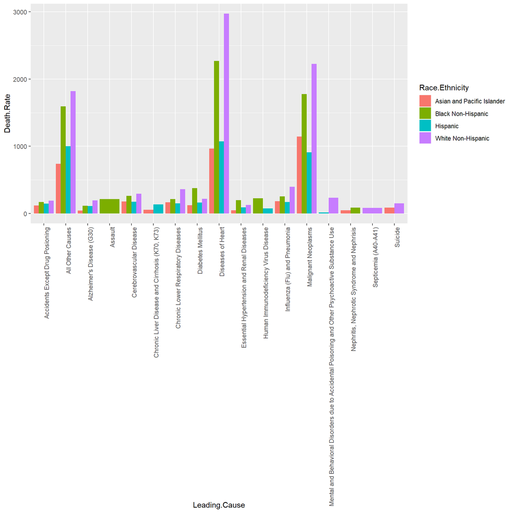

```r
ggplot(data_2014, aes(fill=Race.Ethnicity, y=Death.Rate, x=Leading.Cause)) + geom_bar(position="dodge", stat="identity")+theme(axis.text.x = element_text(angle=90, hjust=1))
```

## result

```r
Heart<-x1[grepl("Diseases of Heart", x1$Leading.Cause),]
Heart
```

```
##        Leading.Cause Sex Asian and Pacific Islander Black Non-Hispanic
## 15 Diseases of Heart   F                        738               2091
## 16 Diseases of Heart   M                        965               2268
##    Hispanic White Non-Hispanic
## 15      971                318
## 16     1073               2971
```

```r
a<- mutate(Heart, total= rowSums (Heart[3:6], na.rm = FALSE, dims = 1))
datatable(a)
```

|  | Leading.Cause | Sex | Asian and Pacific Islander | Black Non-Hispanic | Hispanic | White Non-Hispanic | total |
| --- | --- | --- | --- | --- | --- | --- | --- |
| 1 | Diseases of Heart | F | 738 | 2091 | 971 | 318 | 4118 |
| 2 | Diseases of Heart | M | 965 | 2268 | 1073 | 2971 | 7277 |

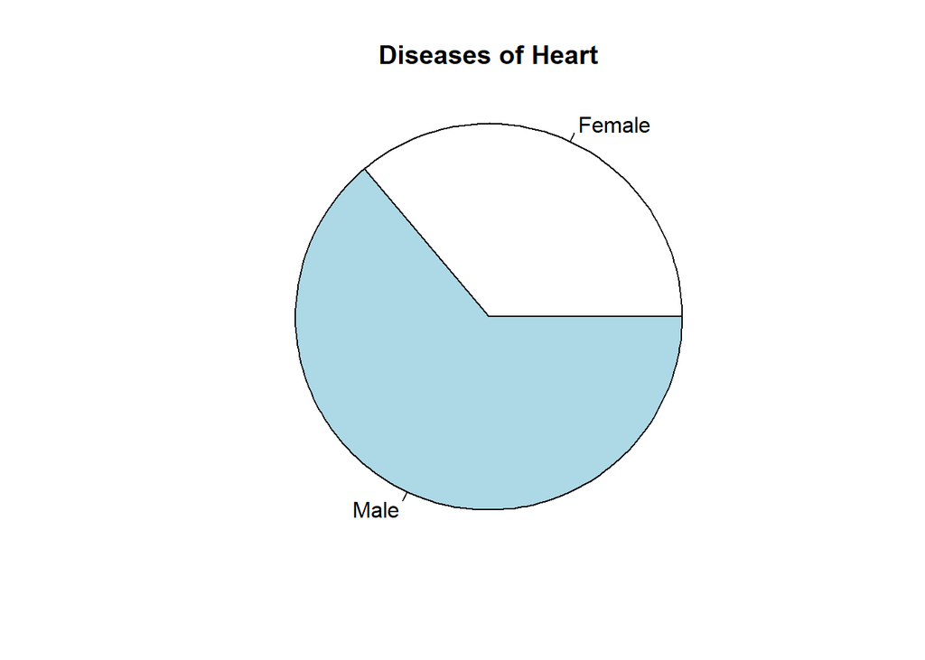

```r
ratio <- a[[2,7]]/a[[1,7]]

pie(a$total, labels = c("Female","Male"), radius = 1, main= "Diseases of Heart")
```

### Ratio of heart disease between males and females is 1.76712 : 1